# GxA results version 10

Andrey Ziyatdinov

2018-03-27

# 1 About

## 1.1 Tables of fine-mapping results

Columns in tables of fine-mapping results (presented below for each locus):

- `zscore`: Z-score of single-SNP association test;
- `pval`: the p-value of single-SNP association test;
- `snp_prob`: the posterior probability of SNP to be causal (estimated by FINEMAP in the region);
- `snp_log10bf`: the associated Bayes Factor (log 10 base);
- `prop_zscore`: the ratio between `zscore` and the best `zscore`;
- `prop_snp_prob`: the ratio between `snp_prob` and the best `snp_prob`.

## 1.2 Overlapping with smoking-dependent methylation QTLs

Article [Genetically contextual effects of smoking on genome wide DNA methylation, 2017, Am J Med Genet B Neuropsychiatr Genet.](https://www.ncbi.nlm.nih.gov/pubmed/28686328)

Data description

- 2,567 inidviduals (of the 5,125 inidividuals in total) have the methylation data measured in blood
- (clean) 484,241 CpG methylation sites measured by the Illumina HumanMethylation450 BeadChip
- (clean) 403,192 SNPs

Results reported in the article:

[output not shown]

- 1M window for cis-effects. Otherwise, trans-effects.
- The outcome is methylation probes (CpG islands).

Limitations:

- The individuals are elderly individuals of European ancestry.
- The methylation arrays is not state-of-the art.

### 1.2.1 Tables of methylation annotations

We mined the significant QTLs based on several filters (the first column in the tables below):

- `smk_by_meth`: interaction signal overlapped with the locus region based on CpG positions;
- `cis_by_meth`: interaction cis-mQTL overlapped with the locus region based on CpG positions;
- `cis_by_snp`: interaction cis-mQTL overlapped with the locus region based on SNP positions;
- `trans_by_meth`: interaction trans-mQTL overlapped with the locus region based on CpG positions;
- `trans_by_snp`: interaction trans-mQTL overlapped with the locus region based on SNP positions;

# 2 Admixed mapping

## 2.1 Manhattan plots

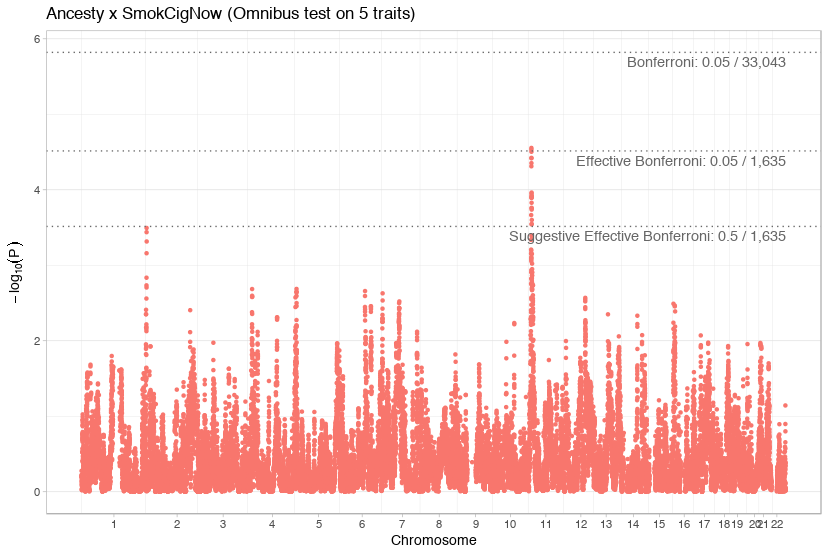

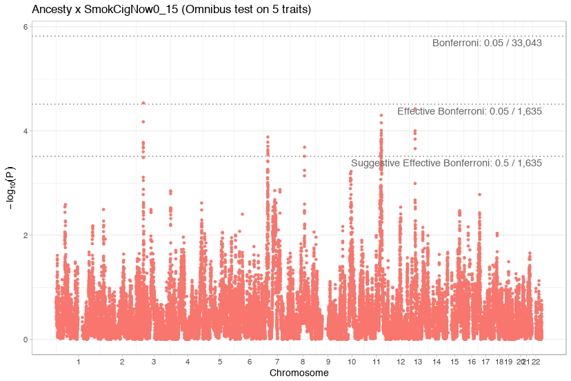

## 2.2 Top loci

| locus | chr | start | end | exposure | mpval | top_trait | spval | mtop_acs | stop_acs | dtop_acs |
| --- | --- | --- | --- | --- | --- | --- | --- | --- | --- | --- |
| 1 | 11 | 12,075,829 | 12,845,835 | SmokCigNow | 2.792e-05 | FEV1pp_utah | 5.861e-06 | chr11acs76888 | chr11acs76871 | 46698 |
| 2 | 2 | 238,143,387 | 238,769,892 | SmokCigNow0_15 | 2.903e-05 | FVC_utah | 2.504e-06 | chr2acs210715 | chr2acs210712 | 0 |
| 3 | 13 | 31,623,839 | 32,256,475 | SmokCigNow0_15 | 3.729e-05 | FEV1_utah | 0.00562 | chr13acs56872 | chr13acs56872 | 0 |
| 4 | 11 | 94,360,812 | 94,825,729 | SmokCigNow0_15 | 4.997e-05 | FEV1_utah | 0.002802 | chr11acs82428 | chr11acs82428 | 0 |
| 5 | 7 | 25,133,849 | 26,371,279 | SmokCigNow0_15 | 0.0001304 | FVCpp_utah | 0.000282 | chr7acs123747 | chr7acs123747 | 0 |
| 6 | 8 | 81,871,222 | 82,335,354 | SmokCigNow0_15 | 0.0002044 | FVC_utah | 0.2441 | chr8acs116593 | chr8acs116593 | 0 |
| 7 | 1 | 248,020,448 | 249,208,153 | SmokCigNow | 0.0003206 | FEV1_FVC_utah | 0.002939 | chr1acs229382 | chr1acs229382 | 0 |

## 2.3 Locus 1

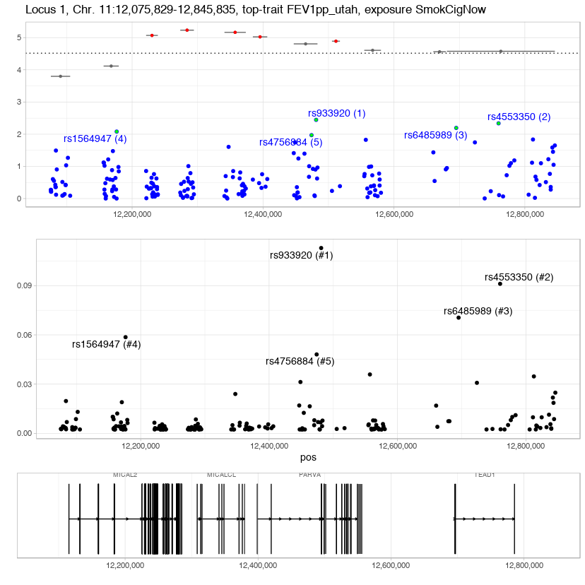

| snp | chr | pos | zscore | pval | snp_prob | snp_log10bf | zscore_acs | pval_acs | prop_zscore | prop_snp_prob |
| --- | --- | --- | --- | --- | --- | --- | --- | --- | --- | --- |
| rs933920 | 11 | 12,481,110 | 2.912 | 0.003587 | 0.1129 | 1.182 | 4.319 | 1.564e-05 | 1 | 1 |
| rs4553350 | 11 | 12,759,834 | -2.833 | 0.004605 | 0.0911 | 1.079 | 4.201 | 2.653e-05 | 1.028 | 1.239 |
| rs6485989 | 11 | 12,695,171 | 2.727 | 0.006391 | 0.0705 | 0.9574 | 4.201 | 2.653e-05 | 1.068 | 1.601 |
| rs1564947 | 11 | 12,176,409 | 2.639 | 0.008311 | 0.0586 | 0.8722 | 3.955 | 7.639e-05 | 1.104 | 1.927 |
| rs4756884 | 11 | 12,474,098 | -2.552 | 0.01072 | 0.0481 | 0.7811 | 4.319 | 1.564e-05 | 1.141 | 2.347 |

### 2.3.1 Overlap with methylation QTLs

NULL NULL

| meth | snp | cpg | beta | pval | gene | chr | start_meth | end_meth | chr_snp | pos_snp |
| --- | --- | --- | --- | --- | --- | --- | --- | --- | --- | --- |
| cis_by_snp | rs16911103 | cg20233228 | -4.258 | 4.41e-13 | TEAD1 | 11 | 12903562 | 12903611 | 11 | 12343740 |
| cis_by_snp | rs16911106 | cg20233228 | -4.165 | 1.58e-12 | TEAD1 | 11 | 12903562 | 12903611 | 11 | 12344805 |

| meth | snp | cpg | beta | pval | gene | chr | start_meth | end_meth | chr_snp | pos_snp |
| --- | --- | --- | --- | --- | --- | --- | --- | --- | --- | --- |
| trans_by_meth | rs17092580 | cg08647724 | -9.054 | NA | PARVA | 11 | 12479811 | 12479860 | NA | NA |
| trans_by_meth | rs11016704 | cg08647724 | -8.961 | NA | PARVA | 11 | 12479811 | 12479860 | NA | NA |
| trans_by_meth | rs9325869 | cg08647724 | -8.973 | NA | PARVA | 11 | 12479811 | 12479860 | NA | NA |
| trans_by_meth | rs12679719 | cg08647724 | -8.96 | NA | PARVA | 11 | 12479811 | 12479860 | NA | NA |
| trans_by_meth | rs10503683 | cg08647724 | -8.969 | NA | PARVA | 11 | 12479811 | 12479860 | NA | NA |
| trans_by_meth | rs28436903 | cg08647724 | -8.955 | NA | PARVA | 11 | 12479811 | 12479860 | NA | NA |
| trans_by_meth | rs9876420 | cg08647724 | -8.963 | NA | PARVA | 11 | 12479811 | 12479860 | NA | NA |
| trans_by_meth | rs1642821 | cg08647724 | -3.777 | NA | PARVA | 11 | 12479811 | 12479860 | NA | NA |
| trans_by_meth | rs41476151 | cg08647724 | -8.745 | NA | PARVA | 11 | 12479811 | 12479860 | NA | NA |
| trans_by_meth | rs3852948 | cg08647724 | -8.683 | NA | PARVA | 11 | 12479811 | 12479860 | NA | NA |
| trans_by_meth | rs522342 | cg25413748 | -8.07 | NA | PARVA | 11 | 12437801 | 12437850 | NA | NA |
| trans_by_meth | rs658709 | cg25413748 | -516.9 | NA | PARVA | 11 | 12437801 | 12437850 | NA | NA |
| trans_by_meth | rs8032425 | cg25413748 | -7.89 | NA | PARVA | 11 | 12437801 | 12437850 | NA | NA |
| trans_by_meth | rs17378623 | cg25413748 | -7.883 | NA | PARVA | 11 | 12437801 | 12437850 | NA | NA |
| trans_by_meth | rs17075139 | cg25413748 | -7.844 | NA | PARVA | 11 | 12437801 | 12437850 | NA | NA |
| trans_by_meth | rs12595828 | cg08647724 | -3.615 | NA | PARVA | 11 | 12479811 | 12479860 | NA | NA |
| trans_by_meth | rs16973100 | cg25413748 | -7.815 | NA | PARVA | 11 | 12437801 | 12437850 | NA | NA |
| trans_by_meth | rs2278186 | cg08647724 | -3.61 | NA | PARVA | 11 | 12479811 | 12479860 | NA | NA |
| trans_by_meth | rs10992236 | cg25413748 | -7.794 | NA | PARVA | 11 | 12437801 | 12437850 | NA | NA |
| trans_by_meth | rs10103224 | cg25413748 | -7.857 | NA | PARVA | 11 | 12437801 | 12437850 | NA | NA |
| trans_by_meth | rs17050780 | cg25413748 | -7.825 | NA | PARVA | 11 | 12437801 | 12437850 | NA | NA |
| trans_by_meth | rs1361886 | cg25413748 | -7.656 | NA | PARVA | 11 | 12437801 | 12437850 | NA | NA |
| trans_by_meth | rs41476151 | cg23384960 | -7.701 | NA | NA | 11 | 12626522 | 12626571 | NA | NA |
| trans_by_meth | rs2226192 | cg25413748 | -7.652 | NA | PARVA | 11 | 12437801 | 12437850 | NA | NA |
| trans_by_meth | rs12570350 | cg25413748 | -7.647 | NA | PARVA | 11 | 12437801 | 12437850 | NA | NA |
| trans_by_meth | rs17092580 | cg23384960 | -7.618 | NA | NA | 11 | 12626522 | 12626571 | NA | NA |
| trans_by_meth | rs17050775 | cg25413748 | -7.612 | NA | PARVA | 11 | 12437801 | 12437850 | NA | NA |
| trans_by_meth | rs12679719 | cg23384960 | -7.593 | NA | NA | 11 | 12626522 | 12626571 | NA | NA |
| trans_by_meth | rs28436903 | cg23384960 | -7.598 | NA | NA | 11 | 12626522 | 12626571 | NA | NA |
| trans_by_meth | rs10503683 | cg23384960 | -7.602 | NA | NA | 11 | 12626522 | 12626571 | NA | NA |
| trans_by_meth | rs9325869 | cg23384960 | -7.59 | NA | NA | 11 | 12626522 | 12626571 | NA | NA |
| trans_by_meth | rs11174810 | cg25413748 | -5.386 | NA | PARVA | 11 | 12437801 | 12437850 | NA | NA |
| trans_by_meth | rs11016704 | cg23384960 | -7.517 | NA | NA | 11 | 12626522 | 12626571 | NA | NA |
| trans_by_meth | rs9876420 | cg23384960 | -7.59 | NA | NA | 11 | 12626522 | 12626571 | NA | NA |
| trans_by_meth | rs3852948 | cg23384960 | -7.51 | NA | NA | 11 | 12626522 | 12626571 | NA | NA |
| trans_by_meth | rs7302283 | cg25413748 | -5.33 | NA | PARVA | 11 | 12437801 | 12437850 | NA | NA |
| trans_by_meth | rs11174816 | cg25413748 | -5.315 | NA | PARVA | 11 | 12437801 | 12437850 | NA | NA |
| trans_by_meth | rs17104720 | cg08647724 | -4.439 | NA | PARVA | 11 | 12479811 | 12479860 | NA | NA |
| trans_by_meth | rs17104722 | cg08647724 | -4.445 | NA | PARVA | 11 | 12479811 | 12479860 | NA | NA |

| meth | snp | cpg | beta | pval | gene | chr | start_meth | end_meth | chr_snp | pos_snp |
| --- | --- | --- | --- | --- | --- | --- | --- | --- | --- | --- |
| trans_by_snp | rs933937 | cg27572826 | 5.082 | 0 | GBAP1 | 1 | 155197173 | 155197222 | 11 | 12525459 |
| trans_by_snp | rs933937 | cg24530610 | -4.429 | 0 | PANK4 | 1 | 2440596 | 2440645 | 11 | 12525459 |
| trans_by_snp | rs4757259 | cg15588905 | -1.994 | 0 | PRSS38 | 1 | 2.28e+08 | 2.28e+08 | 11 | 12215546 |
| trans_by_snp | rs2279617 | cg01719979 | 2.601 | 0 | USF1 | 1 | 1.61e+08 | 1.61e+08 | 11 | 12284950 |
| trans_by_snp | rs17392414 | cg18020955 | 4.279 | 0 | NA | 1 | 147790806 | 147790855 | 11 | 12371577 |
| trans_by_snp | rs16911116 | cg07818949 | -5.112 | 0 | SHC1 | 1 | 154938823 | 154938872 | 11 | 12365095 |
| trans_by_snp | rs16911116 | cg16110314 | -4.213 | 0 | SMYD3 | 1 | 246203635 | 246203684 | 11 | 12365095 |
| trans_by_snp | rs16911106 | cg07818949 | -6.55 | 0 | SHC1 | 1 | 154938823 | 154938872 | 11 | 12344805 |
| trans_by_snp | rs16911106 | cg16110314 | -5.304 | 0 | SMYD3 | 1 | 246203635 | 246203684 | 11 | 12344805 |
| trans_by_snp | rs16911106 | cg16341373 | -4.321 | 0 | CDCA8 | 1 | 38157914 | 38157963 | 11 | 12344805 |
| trans_by_snp | rs16911106 | cg17513697 | -4.28 | 0 | NA | 1 | 17299607 | 17299656 | 11 | 12344805 |
| trans_by_snp | rs16911103 | cg07818949 | -6.581 | 0 | SHC1 | 1 | 154938823 | 154938872 | 11 | 12343740 |
| trans_by_snp | rs16911103 | cg16110314 | -5.392 | 0 | SMYD3 | 1 | 246203635 | 246203684 | 11 | 12343740 |
| trans_by_snp | rs16911103 | cg16341373 | -4.339 | 0 | CDCA8 | 1 | 38157914 | 38157963 | 11 | 12343740 |
| trans_by_snp | rs16911012 | cg24052284 | -3.516 | 0 | NA | 1 | 244806451 | 244806500 | 11 | 12311899 |
| trans_by_snp | rs16911012 | cg22853601 | -3.233 | 0 | KIAA1026 | 1 | 15162073 | 15162122 | 11 | 12311899 |
| trans_by_snp | rs16910545 | cg23232880 | -8.87 | 0 | PADI1 | 1 | 17540662 | 17540711 | 11 | 12141529 |
| trans_by_snp | rs16910545 | cg05375829 | 5.595 | 0 | KLHDC9 | 1 | 161067636 | 161067685 | 11 | 12141529 |
| trans_by_snp | rs16910545 | cg05723953 | 5.453 | 0 | HMGB4 | 1 | 34328907 | 34328956 | 11 | 12141529 |
| trans_by_snp | rs10765955 | cg00171947 | -1.434 | 0 | C1orf216 | 1 | 36185407 | 36185456 | 11 | 12517482 |
| trans_by_snp | rs10741592 | cg00145911 | -8.186 | 0 | SAMD11 | 1 | 867890 | 867939 | 11 | 12492188 |
| trans_by_snp | rs10741592 | cg04788444 | -5.63 | 0 | TRIM11 | 1 | 228584726 | 228584775 | 11 | 12492188 |
| trans_by_snp | rs10741592 | cg19777550 | 4.747 | 0 | PEX10 | 1 | 2344280 | 2344329 | 11 | 12492188 |
| trans_by_snp | rs10741592 | cg19355763 | -4.37 | 0 | CD1A | 1 | 158223465 | 158223514 | 11 | 12492188 |
| trans_by_snp | rs933937 | cg14785392 | -8.228 | NA | NA | 5 | 61180442 | 61180491 | 11 | 12525459 |
| trans_by_snp | rs16910545 | cg25527325 | -8.181 | NA | PLIN5 | 19 | 4523822 | 4523871 | 11 | 12141529 |
| trans_by_snp | rs16911106 | cg19987800 | -6.727 | NA | TNFSF11 | 13 | 43181173 | 43181222 | 11 | 12344805 |
| trans_by_snp | rs16911103 | cg19987800 | -6.705 | NA | TNFSF11 | 13 | 43181173 | 43181222 | 11 | 12343740 |
| trans_by_snp | rs10741592 | cg08492875 | -6.484 | NA | LOC151162 | 2 | 135206071 | 135206120 | 11 | 12492188 |
| trans_by_snp | rs10741592 | cg09459740 | 6.24 | NA | NA | 11 | 108244548 | 108244597 | 11 | 12492188 |

[output cut: 131 more lines]

## 2.4 Locus 2

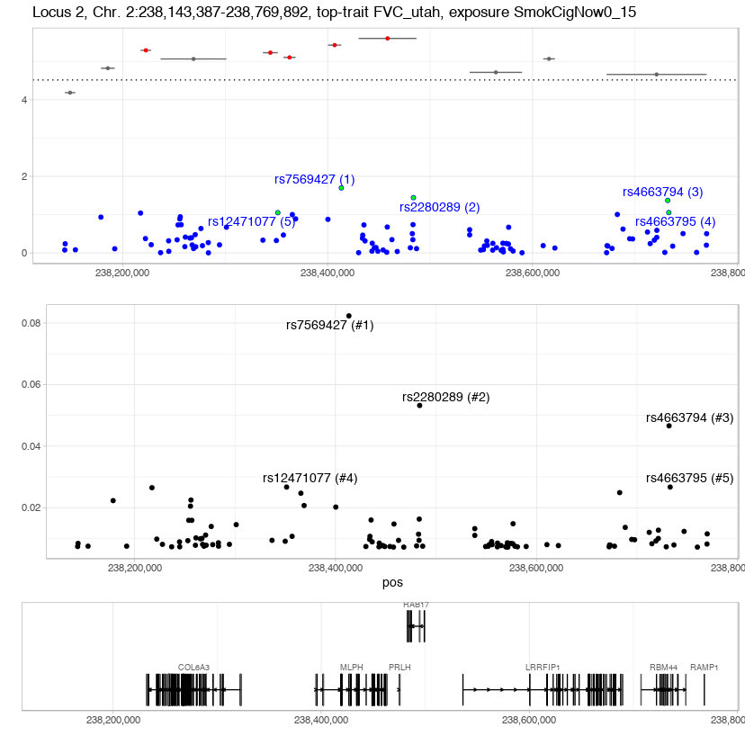

| snp | chr | pos | zscore | pval | snp_prob | snp_log10bf | zscore_acs | pval_acs | prop_zscore | prop_snp_prob |
| --- | --- | --- | --- | --- | --- | --- | --- | --- | --- | --- |
| rs7569427 | 2 | 238,413,338 | -2.325 | 0.02008 | 0.0823 | 0.7621 | 4.625 | 3.742e-06 | 1 | 1 |
| rs2280289 | 2 | 238,483,729 | 2.097 | 0.03599 | 0.0532 | 0.559 | 4.708 | 2.504e-06 | 1.109 | 1.547 |
| rs4663794 | 2 | 238,731,931 | -2.028 | 0.04257 | 0.0466 | 0.4983 | 4.245 | 2.186e-05 | 1.146 | 1.766 |
| rs4663795 | 2 | 238,733,016 | -1.704 | 0.0884 | 0.0267 | 0.2477 | 4.245 | 2.186e-05 | 1.364 | 3.082 |
| rs12471077 | 2 | 238,351,337 | 1.7 | 0.08908 | 0.0267 | 0.248 | 4.53 | 5.91e-06 | 1.367 | 3.082 |

### 2.4.1 Overlap with methylation QTLs

NULL NULL NULL

| meth | snp | cpg | beta | pval | gene | chr | start_meth | end_meth | chr_snp | pos_snp |
| --- | --- | --- | --- | --- | --- | --- | --- | --- | --- | --- |
| trans_by_meth | rs2055456 | cg16266494 | -12 | NA | RAB17 | 2 | 238499734 | 238499783 | NA | NA |
| trans_by_meth | rs9966268 | cg16266494 | -451.9 | NA | RAB17 | 2 | 238499734 | 238499783 | NA | NA |
| trans_by_meth | rs10461740 | cg16266494 | -11.78 | NA | RAB17 | 2 | 238499734 | 238499783 | NA | NA |
| trans_by_meth | rs16995860 | cg16266494 | -5.889 | NA | RAB17 | 2 | 238499734 | 238499783 | NA | NA |
| trans_by_meth | rs3934693 | cg16266494 | -11.6 | NA | RAB17 | 2 | 238499734 | 238499783 | NA | NA |
| trans_by_meth | rs2157608 | cg16266494 | -11.64 | NA | RAB17 | 2 | 238499734 | 238499783 | NA | NA |
| trans_by_meth | rs41500749 | cg16266494 | -4.72 | NA | RAB17 | 2 | 238499734 | 238499783 | NA | NA |
| trans_by_meth | rs34366602 | cg16266494 | -4.71 | NA | RAB17 | 2 | 238499734 | 238499783 | NA | NA |
| trans_by_meth | rs5964719 | cg16266494 | -4.617 | NA | RAB17 | 2 | 238499734 | 238499783 | NA | NA |
| trans_by_meth | rs2045816 | cg10979567 | -9.329 | NA | COL6A3 | 2 | 238241594 | 238241643 | NA | NA |
| trans_by_meth | rs2306135 | cg10979567 | -9.331 | NA | COL6A3 | 2 | 238241594 | 238241643 | NA | NA |
| trans_by_meth | rs2045815 | cg10979567 | -9.331 | NA | COL6A3 | 2 | 238241594 | 238241643 | NA | NA |
| trans_by_meth | rs10148958 | cg10979567 | -9.305 | NA | COL6A3 | 2 | 238241594 | 238241643 | NA | NA |
| trans_by_meth | rs4697298 | cg10979567 | -9.311 | NA | COL6A3 | 2 | 238241594 | 238241643 | NA | NA |
| trans_by_meth | rs602495 | cg10979567 | -9.351 | NA | COL6A3 | 2 | 238241594 | 238241643 | NA | NA |
| trans_by_meth | rs2323523 | cg10979567 | -9.277 | NA | COL6A3 | 2 | 238241594 | 238241643 | NA | NA |
| trans_by_meth | rs17636599 | cg10979567 | -9.318 | NA | COL6A3 | 2 | 238241594 | 238241643 | NA | NA |
| trans_by_meth | rs774394 | cg10979567 | -9.235 | NA | COL6A3 | 2 | 238241594 | 238241643 | NA | NA |
| trans_by_meth | rs17289812 | cg10979567 | -9.134 | NA | COL6A3 | 2 | 238241594 | 238241643 | NA | NA |
| trans_by_meth | rs6938821 | cg10979567 | -9.175 | NA | COL6A3 | 2 | 238241594 | 238241643 | NA | NA |
| trans_by_meth | rs6678126 | cg10979567 | -9.163 | NA | COL6A3 | 2 | 238241594 | 238241643 | NA | NA |
| trans_by_meth | rs12065321 | cg10979567 | -9.162 | NA | COL6A3 | 2 | 238241594 | 238241643 | NA | NA |
| trans_by_meth | rs10493507 | cg10979567 | -9.157 | NA | COL6A3 | 2 | 238241594 | 238241643 | NA | NA |
| trans_by_meth | rs10493506 | cg10979567 | -9.157 | NA | COL6A3 | 2 | 238241594 | 238241643 | NA | NA |
| trans_by_meth | rs11210010 | cg10979567 | -9.157 | NA | COL6A3 | 2 | 238241594 | 238241643 | NA | NA |
| trans_by_meth | rs12066256 | cg10979567 | -9.157 | NA | COL6A3 | 2 | 238241594 | 238241643 | NA | NA |
| trans_by_meth | rs11210002 | cg10979567 | -9.156 | NA | COL6A3 | 2 | 238241594 | 238241643 | NA | NA |
| trans_by_meth | rs10032249 | cg10979567 | -9.074 | NA | COL6A3 | 2 | 238241594 | 238241643 | NA | NA |
| trans_by_meth | rs17093267 | cg10979567 | -9.132 | NA | COL6A3 | 2 | 238241594 | 238241643 | NA | NA |
| trans_by_meth | rs10889991 | cg10979567 | -9.129 | NA | COL6A3 | 2 | 238241594 | 238241643 | NA | NA |

[output cut: 84 more lines]

| meth | snp | cpg | beta | pval | gene | chr | start_meth | end_meth | chr_snp | pos_snp |
| --- | --- | --- | --- | --- | --- | --- | --- | --- | --- | --- |
| trans_by_snp | rs6747872 | cg10861751 | -7.776 | 0 | RGS1 | 1 | 192544668 | 192544717 | 2 | 238203792 |
| trans_by_snp | rs6747872 | cg16347928 | -7.641 | 0 | FLJ39609 | 1 | 854838 | 854887 | 2 | 238203792 |
| trans_by_snp | rs6735617 | cg06929970 | 1.972 | 0 | NA | 1 | 1.82e+08 | 1.82e+08 | 2 | 238685033 |
| trans_by_snp | rs3769074 | cg06929970 | 3.609 | 0 | NA | 1 | 1.82e+08 | 1.82e+08 | 2 | 238646253 |
| trans_by_snp | rs11690358 | cg15588905 | -1.824 | 0 | PRSS38 | 1 | 2.28e+08 | 2.28e+08 | 2 | 238244781 |
| trans_by_snp | rs10171771 | cg17936495 | -9.665 | 0 | SCAMP3 | 1 | 155233003 | 155233052 | 2 | 238180585 |
| trans_by_snp | rs10171771 | cg22614027 | -21.08 | NA | NA | 12 | 76192015 | 76192064 | 2 | 238180585 |
| trans_by_snp | rs6747872 | cg26889826 | -9.495 | NA | PCYT1B | NA | 24691052 | 24691101 | 2 | 238203792 |
| trans_by_snp | rs6431561 | cg15375596 | -4.606 | NA | IGF1R | 15 | 99434688 | 99434737 | 2 | 238711516 |
| trans_by_snp | rs6747872 | cg25815753 | 13.93 | NA | NA | 19 | 1261139 | 1261188 | 2 | 238203792 |
| trans_by_snp | rs10171771 | cg00216180 | -13.52 | NA | RASA3 | 13 | 114778665 | 114778714 | 2 | 238180585 |
| trans_by_snp | rs6747872 | cg10479063 | -13.55 | NA | PZP | 12 | 9360933 | 9360982 | 2 | 238203792 |
| trans_by_snp | rs6431561 | cg26209416 | -4.241 | NA | PLXDC1 | 17 | 37244021 | 37244070 | 2 | 238711516 |
| trans_by_snp | rs10171771 | cg03837909 | 13.13 | NA | NA | 3 | 193505957 | 193506006 | 2 | 238180585 |
| trans_by_snp | rs10171771 | cg18837178 | -12.51 | NA | NA | 5 | 12790981 | 12791030 | 2 | 238180585 |
| trans_by_snp | rs10171771 | cg01492656 | -11.99 | NA | N4BP2 | 4 | 40057193 | 40057242 | 2 | 238180585 |
| trans_by_snp | rs6747872 | cg10091686 | 11.65 | NA | NA | 8 | 12458558 | 12458607 | 2 | 238203792 |
| trans_by_snp | rs6747872 | cg10091686 | 11.65 | NA | NA | 8 | 12458558 | 12458607 | 2 | 238203792 |
| trans_by_snp | rs6747872 | cg21191443 | -11.8 | NA | PTGR1 | 9 | 114363286 | 114363335 | 2 | 238203792 |
| trans_by_snp | rs10171771 | cg15021292 | -11.48 | NA | PIK3R1 | 5 | 67521548 | 67521597 | 2 | 238180585 |
| trans_by_snp | rs3769074 | cg15375596 | -5.288 | NA | IGF1R | 15 | 99434688 | 99434737 | 2 | 238646253 |
| trans_by_snp | rs10171771 | cg08011863 | -11.35 | NA | NA | 6 | 74061333 | 74061382 | 2 | 238180585 |
| trans_by_snp | rs10171771 | cg25999148 | -11.01 | NA | RASA3 | 13 | 114889437 | 114889486 | 2 | 238180585 |
| trans_by_snp | rs903371 | cg15375596 | -4.559 | NA | IGF1R | 15 | 99434688 | 99434737 | 2 | 238639192 |
| trans_by_snp | rs6724129 | cg15375596 | -4.558 | NA | IGF1R | 15 | 99434688 | 99434737 | 2 | 238639268 |
| trans_by_snp | rs6747872 | cg01447951 | -10.09 | NA | FBXL22 | 15 | 63889479 | 63889528 | 2 | 238203792 |
| trans_by_snp | rs6747872 | cg02804722 | -10.49 | NA | EMILIN1 | 2 | 27301009 | 27301058 | 2 | 238203792 |
| trans_by_snp | rs6747872 | cg27207500 | -10.41 | NA | ANKLE2 | 12 | 133317906 | 133317955 | 2 | 238203792 |
| trans_by_snp | rs10171771 | cg00931944 | -10.19 | NA | NA | 8 | 1310046 | 1310095 | 2 | 238180585 |
| trans_by_snp | rs10171771 | cg00931944 | -10.19 | NA | NA | 8 | 1310046 | 1310095 | 2 | 238180585 |

[output cut: 107 more lines]

## 2.5 Locus 3

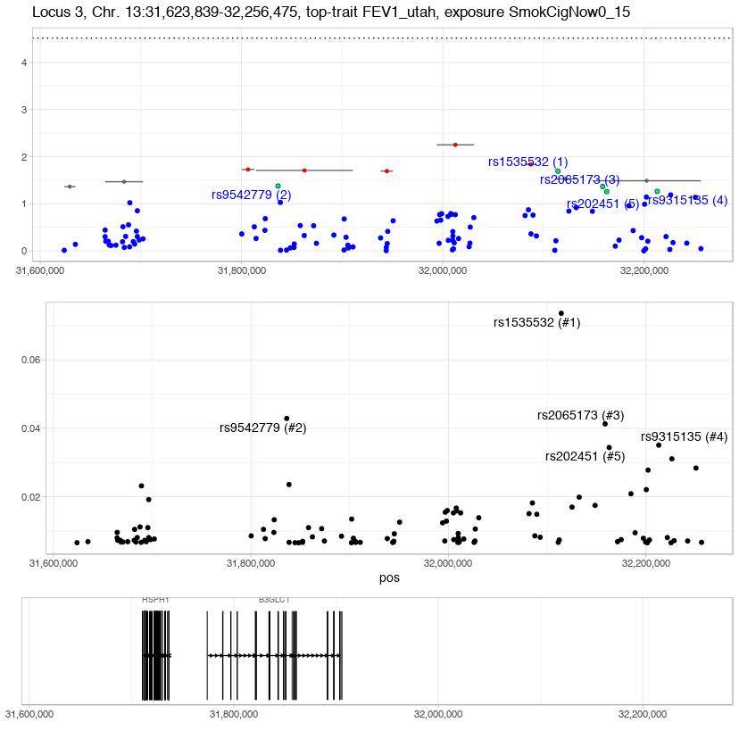

| snp | chr | pos | zscore | pval | snp_prob | snp_log10bf | zscore_acs | pval_acs | prop_zscore | prop_snp_prob |
| --- | --- | --- | --- | --- | --- | --- | --- | --- | --- | --- |
| rs1535532 | 13 | 32,114,398 | 2.319 | 0.02039 | 0.0736 | 0.718 | 2.175 | 0.02962 | 1 | 1 |
| rs9542779 | 13 | 31,836,302 | -2.034 | 0.04193 | 0.0429 | 0.4689 | 2.333 | 0.01964 | 1.14 | 1.716 |
| rs2065173 | 13 | 32,158,849 | 2.023 | 0.04307 | 0.0413 | 0.4525 | 2.137 | 0.03256 | 1.146 | 1.782 |
| rs9315135 | 13 | 32,213,124 | 1.921 | 0.05469 | 0.0351 | 0.3787 | 2.137 | 0.03256 | 1.207 | 2.097 |
| rs202451 | 13 | 32,162,903 | 1.917 | 0.05529 | 0.0344 | 0.3701 | 2.137 | 0.03256 | 1.21 | 2.14 |

### 2.5.1 Overlap with methylation QTLs

NULL NULL NULL

| meth | snp | cpg | beta | pval | gene | chr | start_meth | end_meth | chr_snp | pos_snp |
| --- | --- | --- | --- | --- | --- | --- | --- | --- | --- | --- |
| trans_by_meth | rs3851502 | cg12373003 | -8.173 | NA | NA | 13 | 31943943 | 31943992 | NA | NA |
| trans_by_meth | rs6888637 | cg12373003 | -8.119 | NA | NA | 13 | 31943943 | 31943992 | NA | NA |
| trans_by_meth | rs16963084 | cg12373003 | -8.085 | NA | NA | 13 | 31943943 | 31943992 | NA | NA |
| trans_by_meth | rs11245246 | cg01734284 | -8.081 | NA | B3GALTL | 13 | 31834284 | 31834333 | NA | NA |
| trans_by_meth | rs17732105 | cg12373003 | -463.8 | NA | NA | 13 | 31943943 | 31943992 | NA | NA |
| trans_by_meth | rs6104212 | cg12373003 | -7.892 | NA | NA | 13 | 31943943 | 31943992 | NA | NA |
| trans_by_meth | rs6962826 | cg12373003 | -7.931 | NA | NA | 13 | 31943943 | 31943992 | NA | NA |
| trans_by_meth | rs17154878 | cg12373003 | -7.924 | NA | NA | 13 | 31943943 | 31943992 | NA | NA |
| trans_by_meth | rs17030806 | cg01734284 | -7.916 | NA | B3GALTL | 13 | 31834284 | 31834333 | NA | NA |
| trans_by_meth | rs4260684 | cg12373003 | -7.92 | NA | NA | 13 | 31943943 | 31943992 | NA | NA |
| trans_by_meth | rs7136394 | cg01734284 | -7.915 | NA | B3GALTL | 13 | 31834284 | 31834333 | NA | NA |
| trans_by_meth | rs10122379 | cg01734284 | -7.864 | NA | B3GALTL | 13 | 31834284 | 31834333 | NA | NA |
| trans_by_meth | rs2171193 | cg01734284 | -7.809 | NA | B3GALTL | 13 | 31834284 | 31834333 | NA | NA |
| trans_by_meth | rs1113444 | cg01734284 | -7.813 | NA | B3GALTL | 13 | 31834284 | 31834333 | NA | NA |
| trans_by_meth | rs17124219 | cg12373003 | -7.798 | NA | NA | 13 | 31943943 | 31943992 | NA | NA |
| trans_by_meth | rs4676989 | cg01734284 | -7.747 | NA | B3GALTL | 13 | 31834284 | 31834333 | NA | NA |
| trans_by_meth | rs3945890 | cg01734284 | -7.797 | NA | B3GALTL | 13 | 31834284 | 31834333 | NA | NA |
| trans_by_meth | rs11846527 | cg01734284 | -7.746 | NA | B3GALTL | 13 | 31834284 | 31834333 | NA | NA |
| trans_by_meth | rs6746983 | cg01734284 | -7.713 | NA | B3GALTL | 13 | 31834284 | 31834333 | NA | NA |
| trans_by_meth | rs6746757 | cg01734284 | -7.713 | NA | B3GALTL | 13 | 31834284 | 31834333 | NA | NA |
| trans_by_meth | rs10512600 | cg01734284 | -7.764 | NA | B3GALTL | 13 | 31834284 | 31834333 | NA | NA |
| trans_by_meth | rs17034377 | cg01734284 | -7.73 | NA | B3GALTL | 13 | 31834284 | 31834333 | NA | NA |
| trans_by_meth | rs4428227 | cg01734284 | -7.668 | NA | B3GALTL | 13 | 31834284 | 31834333 | NA | NA |
| trans_by_meth | rs17039813 | cg01734284 | -7.714 | NA | B3GALTL | 13 | 31834284 | 31834333 | NA | NA |
| trans_by_meth | rs12036675 | cg01734284 | -7.617 | NA | B3GALTL | 13 | 31834284 | 31834333 | NA | NA |
| trans_by_meth | rs12062528 | cg01734284 | -7.614 | NA | B3GALTL | 13 | 31834284 | 31834333 | NA | NA |
| trans_by_meth | rs12120383 | cg01734284 | -7.595 | NA | B3GALTL | 13 | 31834284 | 31834333 | NA | NA |
| trans_by_meth | rs3107367 | cg01734284 | -7.586 | NA | B3GALTL | 13 | 31834284 | 31834333 | NA | NA |
| trans_by_meth | rs1878246 | cg01734284 | -7.586 | NA | B3GALTL | 13 | 31834284 | 31834333 | NA | NA |
| trans_by_meth | rs1914132 | cg01734284 | -7.582 | NA | B3GALTL | 13 | 31834284 | 31834333 | NA | NA |
| trans_by_meth | rs1320385 | cg01734284 | -7.575 | NA | B3GALTL | 13 | 31834284 | 31834333 | NA | NA |
| trans_by_meth | rs1914131 | cg01734284 | -7.548 | NA | B3GALTL | 13 | 31834284 | 31834333 | NA | NA |
| trans_by_meth | rs7634403 | cg01734284 | -7.508 | NA | B3GALTL | 13 | 31834284 | 31834333 | NA | NA |
| trans_by_meth | rs16855429 | cg01734284 | -7.431 | NA | B3GALTL | 13 | 31834284 | 31834333 | NA | NA |
| trans_by_meth | rs9295970 | cg01734284 | -7.363 | NA | B3GALTL | 13 | 31834284 | 31834333 | NA | NA |

| meth | snp | cpg | beta | pval | gene | chr | start_meth | end_meth | chr_snp | pos_snp |
| --- | --- | --- | --- | --- | --- | --- | --- | --- | --- | --- |
| trans_by_snp | rs9574660 | cg03794445 | -2.365 | 0 | LOC642587 | 1 | 209605401 | 209605450 | 13 | 31921922 |
| trans_by_snp | rs932714 | cg02934600 | 1.496 | 0 | PRMT6 | 1 | 107600328 | 107600377 | 13 | 31660140 |
| trans_by_snp | rs876540 | cg03794445 | -2.365 | 0 | LOC642587 | 1 | 209605401 | 209605450 | 13 | 31905449 |
| trans_by_snp | rs7982141 | cg15588905 | -6.62 | 0 | PRSS38 | 1 | 2.28e+08 | 2.28e+08 | 13 | 31710355 |
| trans_by_snp | rs7982141 | cg08538869 | -4.668 | 0 | CAPZB | 1 | 19669284 | 19669333 | 13 | 31710355 |
| trans_by_snp | rs7358865 | cg02934600 | 1.377 | 0 | PRMT6 | 1 | 107600328 | 107600377 | 13 | 31669663 |
| trans_by_snp | rs2274190 | cg03794445 | -3.583 | 0 | LOC642587 | 1 | 209605401 | 209605450 | 13 | 31797455 |
| trans_by_snp | rs2224779 | cg02934600 | 1.924 | 0 | PRMT6 | 1 | 107600328 | 107600377 | 13 | 31693041 |
| trans_by_snp | rs17076068 | cg00145911 | -4.149 | 0 | SAMD11 | 1 | 867890 | 867939 | 13 | 3.2e+07 |
| trans_by_snp | rs17076068 | cg01719979 | 3.056 | 0 | USF1 | 1 | 1.61e+08 | 1.61e+08 | 13 | 3.2e+07 |
| trans_by_snp | rs17075436 | cg02934600 | 2.043 | 0 | PRMT6 | 1 | 107600328 | 107600377 | 13 | 31688758 |
| trans_by_snp | rs12584266 | cg00145911 | -2.7 | 0 | SAMD11 | 1 | 867890 | 867939 | 13 | 31994485 |
| trans_by_snp | rs7982141 | cg09326107 | -8.806 | NA | NA | 11 | 41809787 | 41809836 | 13 | 31710355 |
| trans_by_snp | rs7982141 | cg18176922 | 7.163 | NA | SLMO1 | 18 | 12420364 | 12420413 | 13 | 31710355 |
| trans_by_snp | rs2274190 | cg10776839 | -5.74 | NA | NA | 2 | 23935004 | 23935053 | 13 | 31797455 |
| trans_by_snp | rs7982141 | cg03790864 | 6.13 | NA | IREB2 | 15 | 78731104 | 78731153 | 13 | 31710355 |
| trans_by_snp | rs7982141 | cg02259232 | -5.921 | NA | RPL10L | 14 | 47121002 | 47121051 | 13 | 31710355 |
| trans_by_snp | rs9574660 | cg10776839 | -2.858 | NA | NA | 2 | 23935004 | 23935053 | 13 | 31921922 |
| trans_by_snp | rs876540 | cg10776839 | -2.857 | NA | NA | 2 | 23935004 | 23935053 | 13 | 31905449 |
| trans_by_snp | rs9532223 | cg15375596 | -2.085 | NA | IGF1R | 15 | 99434688 | 99434737 | 13 | 32180244 |
| trans_by_snp | rs17076068 | cg14785392 | -4.028 | NA | NA | 5 | 61180442 | 61180491 | 13 | 3.2e+07 |
| trans_by_snp | rs17075436 | cg21481320 | -2.228 | NA | GRWD1 | 19 | 48953799 | 48953848 | 13 | 31688758 |
| trans_by_snp | rs17076068 | cg25187648 | -3.217 | NA | GPX1 | 3 | 49395117 | 49395166 | 13 | 3.2e+07 |
| trans_by_snp | rs7982141 | cg11641080 | -5.383 | NA | SLC4A1AP | 2 | 27893401 | 27893450 | 13 | 31710355 |
| trans_by_snp | rs7358865 | cg16505464 | 1.764 | NA | RFXAP | 13 | 37393242 | 37393291 | 13 | 31669663 |
| trans_by_snp | rs277181 | cg15375596 | -1.793 | NA | IGF1R | 15 | 99434688 | 99434737 | 13 | 32147627 |
| trans_by_snp | rs17076068 | cg14454942 | 3.711 | NA | MUTED | 6 | 8064764 | 8064813 | 13 | 3.2e+07 |
| trans_by_snp | rs2224779 | cg21481320 | -2.048 | NA | GRWD1 | 19 | 48953799 | 48953848 | 13 | 31693041 |
| trans_by_snp | rs202451 | cg15375596 | -1.524 | NA | IGF1R | 15 | 99434688 | 99434737 | 13 | 32162903 |
| trans_by_snp | rs7982141 | cg05785394 | 4.817 | NA | BAT5 | 6 | 31671165 | 31671214 | 13 | 31710355 |
| trans_by_snp | rs2175465 | cg10776839 | -2.773 | NA | NA | 2 | 23935004 | 23935053 | 13 | 31797641 |
| trans_by_snp | rs7982141 | cg15776613 | -4.841 | NA | RAB40B | 17 | 80654141 | 80654190 | 13 | 31710355 |
| trans_by_snp | rs1355478 | cg14785392 | -2.57 | NA | NA | 5 | 61180442 | 61180491 | 13 | 31838560 |
| trans_by_snp | rs7982141 | cg22856771 | -4.556 | NA | NA | 11 | 121665788 | 121665837 | 13 | 31710355 |
| trans_by_snp | rs2274190 | cg23845206 | 3.855 | NA | FAHD2B | 2 | 97760678 | 97760727 | 13 | 31797455 |
| trans_by_snp | rs9532223 | cg26209416 | -1.739 | NA | PLXDC1 | 17 | 37244021 | 37244070 | 13 | 32180244 |
| trans_by_snp | rs12584266 | cg14454942 | 2.731 | NA | MUTED | 6 | 8064764 | 8064813 | 13 | 31994485 |
| trans_by_snp | rs12584266 | cg08492875 | -2.816 | NA | LOC151162 | 2 | 135206071 | 135206120 | 13 | 31994485 |
| trans_by_snp | rs7982141 | cg21814178 | 4.536 | NA | NA | 12 | 51720707 | 51720756 | 13 | 31710355 |
| trans_by_snp | rs7982141 | cg18123399 | 4.469 | NA | TMEM161B | 5 | 87565030 | 87565079 | 13 | 31710355 |
| trans_by_snp | rs7982141 | cg11979591 | 4.505 | NA | ZNF563 | 19 | 12444583 | 12444632 | 13 | 31710355 |
| trans_by_snp | rs7982141 | cg18307966 | -4.358 | NA | ACTR3B | 7 | 152532228 | 152532277 | 13 | 31710355 |
| trans_by_snp | rs277181 | cg26209416 | -1.517 | NA | PLXDC1 | 17 | 37244021 | 37244070 | 13 | 32147627 |
| trans_by_snp | rs7982141 | cg13749266 | -4.481 | NA | GLIS3 | 9 | 4133064 | 4133113 | 13 | 31710355 |
| trans_by_snp | rs17076139 | cg07427396 | 3.257 | NA | SPRYD4 | 12 | 56862729 | 56862778 | 13 | 32028709 |
| trans_by_snp | rs12584266 | cg25187648 | -2.243 | NA | GPX1 | 3 | 49395117 | 49395166 | 13 | 31994485 |
| trans_by_snp | rs932714 | cg21481320 | -1.555 | NA | GRWD1 | 19 | 48953799 | 48953848 | 13 | 31660140 |
| trans_by_snp | rs17076141 | cg07427396 | 3.233 | NA | SPRYD4 | 12 | 56862729 | 56862778 | 13 | 32030865 |
| trans_by_snp | rs7982141 | cg03051003 | -4.428 | NA | NA | 2 | 72013983 | 72014032 | 13 | 31710355 |
| trans_by_snp | rs12584266 | cg14785392 | -2.71 | NA | NA | 5 | 61180442 | 61180491 | 13 | 31994485 |
| trans_by_snp | rs2077796 | cg07427396 | 3.218 | NA | SPRYD4 | 12 | 56862729 | 56862778 | 13 | 32041630 |
| trans_by_snp | rs7982141 | cg26483081 | 4.183 | NA | TMEM161B | 5 | 87564747 | 87564796 | 13 | 31710355 |
| trans_by_snp | rs7358865 | cg21101714 | -1.44 | NA | C3orf67 | 3 | 58802309 | 58802358 | 13 | 31669663 |
| trans_by_snp | rs7358865 | cg21481320 | -1.443 | NA | GRWD1 | 19 | 48953799 | 48953848 | 13 | 31669663 |
| trans_by_snp | rs7982141 | cg10616306 | 4.33 | NA | TMEM161B | 5 | 87564718 | 87564767 | 13 | 31710355 |
| trans_by_snp | rs12584266 | cg19601991 | 2.581 | NA | 6-Mar | 5 | 10353387 | 10353436 | 13 | 31994485 |
| trans_by_snp | rs9574660 | cg00900231 | -2.122 | NA | NA | 16 | 50897271 | 50897320 | 13 | 31921922 |

## 2.6 Locus 4

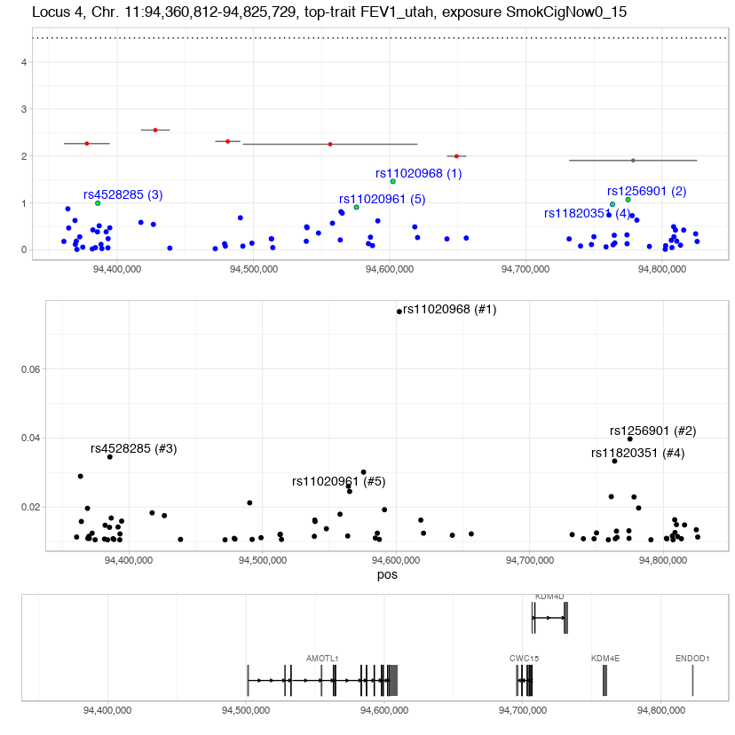

| snp | chr | pos | zscore | pval | snp_prob | snp_log10bf | zscore_acs | pval_acs | prop_zscore | prop_snp_prob |
| --- | --- | --- | --- | --- | --- | --- | --- | --- | --- | --- |
| rs11020968 | 11 | 94,602,414 | -2.111 | 0.03481 | 0.0766 | 0.611 | 2.769 | 0.005617 | 1 | 1 |
| rs1256901 | 11 | 94,775,030 | 1.722 | 0.08511 | 0.0397 | 0.3089 | 2.499 | 0.01245 | 1.226 | 1.929 |
| rs4528285 | 11 | 94,385,718 | -1.638 | 0.1013 | 0.0345 | 0.246 | 2.78 | 0.005437 | 1.288 | 2.22 |
| rs11820351 | 11 | 94,763,545 | -1.612 | 0.107 | 0.0333 | 0.2288 | 2.499 | 0.01245 | 1.309 | 2.3 |
| rs11020961 | 11 | 94,575,608 | -1.54 | 0.1235 | 0.0301 | 0.1839 | 2.769 | 0.005617 | 1.37 | 2.545 |

### 2.6.1 Overlap with methylation QTLs

NULL NULL NULL

| meth | snp | cpg | beta | pval | gene | chr | start_meth | end_meth | chr_snp | pos_snp |
| --- | --- | --- | --- | --- | --- | --- | --- | --- | --- | --- |
| trans_by_meth | rs16979977 | cg15616310 | -9.929 | NA | AMOTL1 | 11 | 94570647 | 94570696 | NA | NA |
| trans_by_meth | rs11083234 | cg15616310 | -9.771 | NA | AMOTL1 | 11 | 94570647 | 94570696 | NA | NA |
| trans_by_meth | rs992435 | cg15616310 | -9.786 | NA | AMOTL1 | 11 | 94570647 | 94570696 | NA | NA |
| trans_by_meth | rs319490 | cg15616310 | -9.665 | NA | AMOTL1 | 11 | 94570647 | 94570696 | NA | NA |
| trans_by_meth | rs12058607 | cg15616310 | -9.607 | NA | AMOTL1 | 11 | 94570647 | 94570696 | NA | NA |
| trans_by_meth | rs9926939 | cg15616310 | -9.593 | NA | AMOTL1 | 11 | 94570647 | 94570696 | NA | NA |
| trans_by_meth | rs16929836 | cg15616310 | -4.88 | NA | AMOTL1 | 11 | 94570647 | 94570696 | NA | NA |
| trans_by_meth | rs519507 | cg15616310 | -9.462 | NA | AMOTL1 | 11 | 94570647 | 94570696 | NA | NA |
| trans_by_meth | rs2053026 | cg15616310 | -9.406 | NA | AMOTL1 | 11 | 94570647 | 94570696 | NA | NA |
| trans_by_meth | rs7174562 | cg06757670 | 8.407 | NA | NA | 11 | 94480048 | 94480097 | NA | NA |
| trans_by_meth | rs16900482 | cg06757670 | 8.294 | NA | NA | 11 | 94480048 | 94480097 | NA | NA |
| trans_by_meth | rs17837717 | cg06757670 | 8.265 | NA | NA | 11 | 94480048 | 94480097 | NA | NA |
| trans_by_meth | rs13413002 | cg06757670 | 442.5 | NA | NA | 11 | 94480048 | 94480097 | NA | NA |
| trans_by_meth | rs12943994 | cg06757670 | 8.128 | NA | NA | 11 | 94480048 | 94480097 | NA | NA |
| trans_by_meth | rs16916572 | cg06757670 | 8.13 | NA | NA | 11 | 94480048 | 94480097 | NA | NA |
| trans_by_meth | rs8068876 | cg06757670 | 8.106 | NA | NA | 11 | 94480048 | 94480097 | NA | NA |
| trans_by_meth | rs7212406 | cg06757670 | 8.105 | NA | NA | 11 | 94480048 | 94480097 | NA | NA |
| trans_by_meth | rs7012794 | cg06757670 | 8.09 | NA | NA | 11 | 94480048 | 94480097 | NA | NA |
| trans_by_meth | rs2471041 | cg06757670 | 8.135 | NA | NA | 11 | 94480048 | 94480097 | NA | NA |
| trans_by_meth | rs7190256 | cg06757670 | 8.124 | NA | NA | 11 | 94480048 | 94480097 | NA | NA |
| trans_by_meth | rs7595401 | cg06757670 | 8.047 | NA | NA | 11 | 94480048 | 94480097 | NA | NA |
| trans_by_meth | rs11072441 | cg06757670 | 8.099 | NA | NA | 11 | 94480048 | 94480097 | NA | NA |
| trans_by_meth | rs11072442 | cg06757670 | 8.11 | NA | NA | 11 | 94480048 | 94480097 | NA | NA |
| trans_by_meth | rs10054518 | cg06757670 | 8.082 | NA | NA | 11 | 94480048 | 94480097 | NA | NA |
| trans_by_meth | rs460976 | cg06757670 | 8.049 | NA | NA | 11 | 94480048 | 94480097 | NA | NA |
| trans_by_meth | rs6883592 | cg06757670 | 7.997 | NA | NA | 11 | 94480048 | 94480097 | NA | NA |
| trans_by_meth | rs4566615 | cg15616310 | -5.482 | NA | AMOTL1 | 11 | 94570647 | 94570696 | NA | NA |
| trans_by_meth | rs359058 | cg15616310 | -5.486 | NA | AMOTL1 | 11 | 94570647 | 94570696 | NA | NA |
| trans_by_meth | rs359109 | cg15616310 | -5.486 | NA | AMOTL1 | 11 | 94570647 | 94570696 | NA | NA |
| trans_by_meth | rs17082321 | cg15616310 | -5.451 | NA | AMOTL1 | 11 | 94570647 | 94570696 | NA | NA |
| trans_by_meth | rs16917049 | cg06757670 | 3.514 | NA | NA | 11 | 94480048 | 94480097 | NA | NA |
| trans_by_meth | rs4774826 | cg15616310 | -5.358 | NA | AMOTL1 | 11 | 94570647 | 94570696 | NA | NA |
| trans_by_meth | rs4800833 | cg15616310 | -5.293 | NA | AMOTL1 | 11 | 94570647 | 94570696 | NA | NA |

| meth | snp | cpg | beta | pval | gene | chr | start_meth | end_meth | chr_snp | pos_snp |
| --- | --- | --- | --- | --- | --- | --- | --- | --- | --- | --- |
| trans_by_snp | rs7952213 | cg11465163 | -3.394 | 0 | DIRAS3 | 1 | 68516093 | 68516142 | 11 | 94580544 |
| trans_by_snp | rs7931003 | cg27572826 | 16.65 | 0 | GBAP1 | 1 | 155197173 | 155197222 | 11 | 94779605 |
| trans_by_snp | rs7931003 | cg24530610 | -13.99 | 0 | PANK4 | 1 | 2440596 | 2440645 | 11 | 94779605 |
| trans_by_snp | rs7931003 | cg17143270 | -8.642 | 0 | NA | 1 | 91532771 | 91532820 | 11 | 94779605 |
| trans_by_snp | rs7931003 | cg10993488 | -8.236 | 0 | PLA2G2A | 1 | 20304914 | 20304963 | 11 | 94779605 |
| trans_by_snp | rs7931003 | cg13735697 | -7.637 | 0 | MYOG | 1 | 203055248 | 203055297 | 11 | 94779605 |
| trans_by_snp | rs7113554 | cg01923523 | -4.033 | 0 | LRRC47 | 1 | 3712606 | 3712655 | 11 | 94479361 |
| trans_by_snp | rs3740863 | cg18537410 | -4.371 | 0 | DNAJC11 | 1 | 6749392 | 6749441 | 11 | 94601935 |
| trans_by_snp | rs16921158 | cg21109518 | -2.527 | 0 | MPL | 1 | 43819265 | 43819314 | 11 | 94661151 |
| trans_by_snp | rs533043 | cg17050632 | -8.526 | NA | EIF2C2 | 8 | 141577526 | 141577575 | 11 | 94609119 |
| trans_by_snp | rs533043 | cg17050632 | -8.526 | NA | EIF2C2 | 8 | 141577526 | 141577575 | 11 | 94609119 |
| trans_by_snp | rs690443 | cg17050632 | -8.518 | NA | EIF2C2 | 8 | 141577526 | 141577575 | 11 | 94610393 |
| trans_by_snp | rs690443 | cg17050632 | -8.518 | NA | EIF2C2 | 8 | 141577526 | 141577575 | 11 | 94610393 |
| trans_by_snp | rs7931003 | cg05181397 | -14.17 | NA | C17orf101 | 17 | 80362150 | 80362199 | 11 | 94779605 |
| trans_by_snp | rs7931003 | cg16973107 | -14.15 | NA | INHBC | 12 | 57828180 | 57828229 | 11 | 94779605 |
| trans_by_snp | rs7931003 | cg26238727 | -13.04 | NA | UGT1A10 | 2 | 234545062 | 234545111 | 11 | 94779605 |
| trans_by_snp | rs7931003 | cg14696468 | -12.86 | NA | KCTD11 | 17 | 7256577 | 7256626 | 11 | 94779605 |
| trans_by_snp | rs7931003 | cg01493020 | -12.81 | NA | CLCN7 | 16 | 1518201 | 1518250 | 11 | 94779605 |
| trans_by_snp | rs3740863 | cg04958654 | -7.269 | NA | ZNF550 | 19 | 58069072 | 58069121 | 11 | 94601935 |
| trans_by_snp | rs193083 | cg17050632 | -5.656 | NA | EIF2C2 | 8 | 141577526 | 141577575 | 11 | 94600574 |
| trans_by_snp | rs193083 | cg17050632 | -5.656 | NA | EIF2C2 | 8 | 141577526 | 141577575 | 11 | 94600574 |
| trans_by_snp | rs333024 | cg17050632 | -5.609 | NA | EIF2C2 | 8 | 141577526 | 141577575 | 11 | 94590463 |
| trans_by_snp | rs333024 | cg17050632 | -5.609 | NA | EIF2C2 | 8 | 141577526 | 141577575 | 11 | 94590463 |
| trans_by_snp | rs7952213 | cg17050632 | -5.593 | NA | EIF2C2 | 8 | 141577526 | 141577575 | 11 | 94580544 |
| trans_by_snp | rs7952213 | cg17050632 | -5.593 | NA | EIF2C2 | 8 | 141577526 | 141577575 | 11 | 94580544 |
| trans_by_snp | rs7931003 | cg17803235 | -12.04 | NA | MAD1L1 | 7 | 2165640 | 2165689 | 11 | 94779605 |
| trans_by_snp | rs7113554 | cg22996592 | -5.654 | NA | HCFC1 | NA | 153220639 | 153220688 | 11 | 94479361 |
| trans_by_snp | rs7113554 | cg22413090 | -6.193 | NA | NCRNA00171 | 6 | 29986712 | 29986761 | 11 | 94479361 |
| trans_by_snp | rs3740863 | cg03742724 | -6.747 | NA | PARK2 | 6 | 161838949 | 161838998 | 11 | 94601935 |
| trans_by_snp | rs16921158 | cg05949877 | -3.808 | NA | NCRNA00171 | 6 | 30019868 | 30019917 | 11 | 94661151 |

[output cut: 146 more lines]

## 2.7 Locus 5

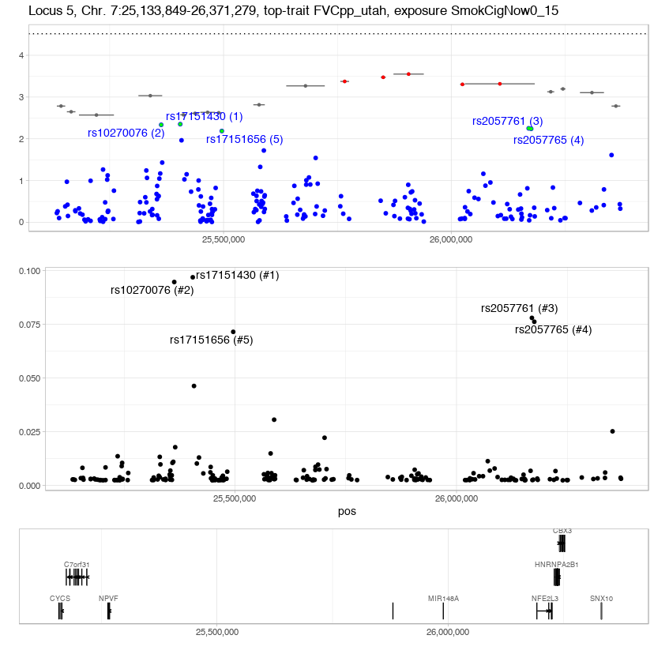

| snp | chr | pos | zscore | pval | snp_prob | snp_log10bf | zscore_acs | pval_acs | prop_zscore | prop_snp_prob |
| --- | --- | --- | --- | --- | --- | --- | --- | --- | --- | --- |
| rs17151430 | 7 | 25,404,838 | 2.844 | 0.004462 | 0.0969 | 1.144 | 3.004 | 0.002667 | 1 | 1 |
| rs10270076 | 7 | 25,363,037 | -2.832 | 0.004628 | 0.0947 | 1.132 | 3.311 | 0.0009281 | 1.004 | 1.023 |
| rs2057761 | 7 | 26,170,112 | 2.769 | 0.005619 | 0.078 | 1.04 | 3.49 | 0.0004823 | 1.027 | 1.242 |
| rs2057765 | 7 | 26,175,542 | 2.761 | 0.005766 | 0.0762 | 1.03 | 3.49 | 0.0004823 | 1.03 | 1.272 |
| rs17151656 | 7 | 25,496,143 | 2.721 | 0.006512 | 0.0715 | 0.9995 | 3.038 | 0.002382 | 1.045 | 1.355 |

### 2.7.1 Overlap with methylation QTLs

Relevant publications:

- [Nfe2l3 (Nrf3) deficiency predisposes mice to T-cell lymphoblastic lymphoma, Blood 2011](https://www.ncbi.nlm.nih.gov/pubmed/21148084)

| meth | cpg | beta | pval | pval_bf | gene | chr | start_meth | end_meth |
| --- | --- | --- | --- | --- | --- | --- | --- | --- |
| smk_by_meth | cg08822075 | -0.5866 | 1.79e-10 | 8.69e-05 | NFE2L3 | 7 | 26193559 | 26193608 |

NULL NULL

| meth | snp | cpg | beta | pval | gene | chr | start_meth | end_meth | chr_snp | pos_snp |
| --- | --- | --- | --- | --- | --- | --- | --- | --- | --- | --- |
| trans_by_meth | rs10992722 | cg03594908 | -8.758 | NA | NA | 7 | 25897344 | 25897393 | NA | NA |
| trans_by_meth | rs17044582 | cg11010242 | -8.728 | NA | CBX3 | 7 | 26240470 | 26240519 | NA | NA |
| trans_by_meth | rs17105726 | cg11010242 | -8.764 | NA | CBX3 | 7 | 26240470 | 26240519 | NA | NA |
| trans_by_meth | rs556506 | cg11010242 | -8.642 | NA | CBX3 | 7 | 26240470 | 26240519 | NA | NA |
| trans_by_meth | rs942927 | cg03594908 | -8.578 | NA | NA | 7 | 25897344 | 25897393 | NA | NA |
| trans_by_meth | rs6638372 | cg03594908 | -8.578 | NA | NA | 7 | 25897344 | 25897393 | NA | NA |
| trans_by_meth | rs16911871 | cg11010242 | -8.605 | NA | CBX3 | 7 | 26240470 | 26240519 | NA | NA |
| trans_by_meth | rs8132190 | cg11010242 | -8.514 | NA | CBX3 | 7 | 26240470 | 26240519 | NA | NA |
| trans_by_meth | rs10879976 | cg11010242 | -8.392 | NA | CBX3 | 7 | 26240470 | 26240519 | NA | NA |
| trans_by_meth | rs10879974 | cg11010242 | -8.35 | NA | CBX3 | 7 | 26240470 | 26240519 | NA | NA |
| trans_by_meth | rs11180671 | cg11010242 | -8.335 | NA | CBX3 | 7 | 26240470 | 26240519 | NA | NA |
| trans_by_meth | rs2185225 | cg11010242 | -3.677 | NA | CBX3 | 7 | 26240470 | 26240519 | NA | NA |
| trans_by_meth | rs2253404 | cg03594908 | -3.59 | NA | NA | 7 | 25897344 | 25897393 | NA | NA |
| trans_by_meth | rs794232 | cg11010242 | -5.47 | NA | CBX3 | 7 | 26240470 | 26240519 | NA | NA |

| meth | snp | cpg | beta | pval | gene | chr | start_meth | end_meth | chr_snp | pos_snp |
| --- | --- | --- | --- | --- | --- | --- | --- | --- | --- | --- |
| trans_by_snp | rs4719827 | cg00145911 | -2.711 | 0 | SAMD11 | 1 | 867890 | 867939 | 7 | 25814641 |
| trans_by_snp | rs41374744 | cg04830546 | -4.229 | 0 | NA | 1 | 95969622 | 95969671 | 7 | 26227855 |
| trans_by_snp | rs2237330 | cg04830546 | -5.973 | 0 | NA | 1 | 95969622 | 95969671 | 7 | 26213396 |
| trans_by_snp | rs2237330 | cg25593075 | -4.367 | 0 | LENEP | 1 | 1.55e+08 | 1.55e+08 | 7 | 26213396 |
| trans_by_snp | rs17152880 | cg18020955 | 3.727 | 0 | NA | 1 | 147790806 | 147790855 | 7 | 25924084 |
| trans_by_snp | rs12112911 | cg07022289 | -367.3 | 0 | NA | 1 | 238226241 | 238226290 | 7 | 26297445 |
| trans_by_snp | rs12112911 | cg17741818 | 276.2 | 0 | RUSC1 | 1 | 155293914 | 155293963 | 7 | 26297445 |
| trans_by_snp | rs12112911 | cg03580801 | -241.2 | 0 | SDF4 | 1 | 1153690 | 1153739 | 7 | 26297445 |
| trans_by_snp | rs12112911 | cg24412204 | -238.2 | 0 | NA | 1 | 240934923 | 240934972 | 7 | 26297445 |
| trans_by_snp | rs11765793 | cg00171947 | -1.308 | 0 | C1orf216 | 1 | 36185407 | 36185456 | 7 | 25370035 |
| trans_by_snp | rs10268531 | cg00171947 | -1.637 | 0 | C1orf216 | 1 | 36185407 | 36185456 | 7 | 25307640 |
| trans_by_snp | rs12112911 | cg04956674 | -546.6 | NA | TRIM26 | 6 | 30171485 | 30171534 | 7 | 26297445 |
| trans_by_snp | rs12112911 | cg15474769 | -314.4 | NA | TSPYL2 | NA | 53113474 | 53113523 | 7 | 26297445 |
| trans_by_snp | rs12112911 | cg20191740 | 409.1 | NA | C6orf25 | 6 | 31691354 | 31691403 | 7 | 26297445 |
| trans_by_snp | rs12112911 | cg25893906 | -403.5 | NA | HUNK | 21 | 33371539 | 33371588 | 7 | 26297445 |
| trans_by_snp | rs12112911 | cg23087358 | -359.8 | NA | GLI2 | 2 | 121745872 | 121745921 | 7 | 26297445 |
| trans_by_snp | rs12112911 | cg01247856 | -356.1 | NA | GCNT3 | 15 | 59911770 | 59911819 | 7 | 26297445 |
| trans_by_snp | rs12112911 | cg13696012 | -347.9 | NA | BPIL1 | 20 | 31595312 | 31595361 | 7 | 26297445 |
| trans_by_snp | rs12112911 | cg05360371 | -340.8 | NA | GLI2 | 2 | 121746437 | 121746486 | 7 | 26297445 |
| trans_by_snp | rs12112911 | cg01851970 | -346.7 | NA | NA | 5 | 73579196 | 73579245 | 7 | 26297445 |
| trans_by_snp | rs12112911 | cg22298265 | -349.1 | NA | NA | 8 | 975286 | 975335 | 7 | 26297445 |
| trans_by_snp | rs12112911 | cg22298265 | -349.1 | NA | NA | 8 | 975286 | 975335 | 7 | 26297445 |
| trans_by_snp | rs12112911 | cg00368296 | -342.2 | NA | ELAVL1 | 19 | 8052135 | 8052184 | 7 | 26297445 |
| trans_by_snp | rs12112911 | cg18654665 | -345.5 | NA | MYPN | 10 | 69898847 | 69898896 | 7 | 26297445 |
| trans_by_snp | rs12112911 | cg18519450 | -335.6 | NA | GLI2 | 2 | 121746027 | 121746076 | 7 | 26297445 |
| trans_by_snp | rs12112911 | cg23843180 | -314.8 | NA | NGEF | 2 | 233852791 | 233852840 | 7 | 26297445 |
| trans_by_snp | rs7794566 | cg15172011 | 5.273 | NA | NA | 8 | 40290016 | 40290065 | 7 | 25495464 |
| trans_by_snp | rs7794566 | cg15172011 | 5.273 | NA | NA | 8 | 40290016 | 40290065 | 7 | 25495464 |
| trans_by_snp | rs12112911 | cg05573818 | -325.7 | NA | RASA3 | 13 | 114781972 | 114782021 | 7 | 26297445 |
| trans_by_snp | rs12112911 | cg03455255 | -310.5 | NA | TSPYL6 | 2 | 54483145 | 54483194 | 7 | 26297445 |

[output cut: 129 more lines]

## 2.8 Locus 6

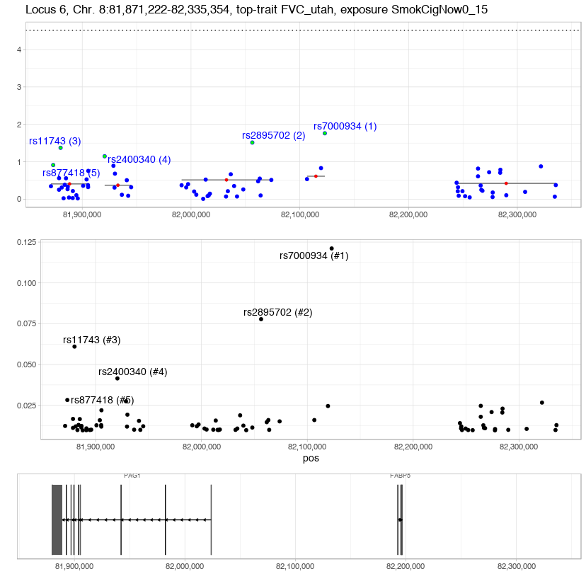

| snp | chr | pos | zscore | pval | snp_prob | snp_log10bf | zscore_acs | pval_acs | prop_zscore | prop_snp_prob |
| --- | --- | --- | --- | --- | --- | --- | --- | --- | --- | --- |
| rs7000934 | 8 | 82,123,005 | -2.379 | 0.01736 | 0.1211 | 0.8084 | -1.165 | 0.2441 | 1 | 1 |
| rs2895702 | 8 | 82,056,340 | 2.161 | 0.0307 | 0.0778 | 0.5954 | -1.023 | 0.3065 | 1.101 | 1.557 |
| rs11743 | 8 | 81,880,096 | 2.029 | 0.04243 | 0.061 | 0.4823 | -0.8557 | 0.3922 | 1.172 | 1.985 |
| rs2400340 | 8 | 81,920,610 | 1.803 | 0.07141 | 0.0415 | 0.3059 | -0.7983 | 0.4247 | 1.32 | 2.918 |
| rs877418 | 8 | 81,873,308 | 1.544 | 0.1227 | 0.0283 | 0.1337 | -0.8557 | 0.3922 | 1.541 | 4.279 |

### 2.8.1 Overlap with methylation QTLs

NULL NULL NULL NULL

| meth | snp | cpg | beta | pval | gene | chr | start_meth | end_meth | chr_snp | pos_snp |
| --- | --- | --- | --- | --- | --- | --- | --- | --- | --- | --- |
| trans_by_snp | rs454550 | cg07818949 | -3.337 | 0 | SHC1 | 1 | 154938823 | 154938872 | 8 | 82191652 |
| trans_by_snp | rs454550 | cg24341759 | -2.121 | 0 | SSBP3 | 1 | 54769801 | 54769850 | 8 | 82191652 |
| trans_by_snp | rs1909936 | cg19777550 | 4.11 | 0 | PEX10 | 1 | 2344280 | 2344329 | 8 | 82245451 |
| trans_by_snp | rs1909936 | cg15172011 | 6.078 | NA | NA | 8 | 40290016 | 40290065 | 8 | 82245451 |
| trans_by_snp | rs1909936 | cg15172011 | 6.078 | NA | NA | 8 | 40290016 | 40290065 | 8 | 82245451 |
| trans_by_snp | rs11986666 | cg13725636 | -3.202 | NA | DLGAP2 | 8 | 1471398 | 1471447 | 8 | 81961455 |
| trans_by_snp | rs11986666 | cg13725636 | -3.202 | NA | DLGAP2 | 8 | 1471398 | 1471447 | 8 | 81961455 |
| trans_by_snp | rs1909936 | cg14804706 | -5.9 | NA | CD81 | 11 | 2416701 | 2416750 | 8 | 82245451 |
| trans_by_snp | rs454550 | cg19987800 | -2.987 | NA | TNFSF11 | 13 | 43181173 | 43181222 | 8 | 82191652 |
| trans_by_snp | rs11986666 | cg23705060 | -2.563 | NA | EP400 | 12 | 132443356 | 132443405 | 8 | 81961455 |
| trans_by_snp | rs454550 | cg02445536 | -2.563 | NA | NA | 10 | 9449524 | 9449573 | 8 | 82191652 |
| trans_by_snp | rs1909936 | cg01773760 | 4.812 | NA | SETD6 | 16 | 58549251 | 58549300 | 8 | 82245451 |
| trans_by_snp | rs1909936 | cg16813459 | -4.821 | NA | TFG | 3 | 100430811 | 100430860 | 8 | 82245451 |
| trans_by_snp | rs1909935 | cg15172011 | 3.412 | NA | NA | 8 | 40290016 | 40290065 | 8 | 82245360 |
| trans_by_snp | rs1909935 | cg15172011 | 3.412 | NA | NA | 8 | 40290016 | 40290065 | 8 | 82245360 |
| trans_by_snp | rs1909936 | cg12583908 | 4.553 | NA | RFC4 | 3 | 186524777 | 186524826 | 8 | 82245451 |
| trans_by_snp | rs1909936 | cg02615561 | -4.487 | NA | NA | 5 | 137575158 | 137575207 | 8 | 82245451 |
| trans_by_snp | rs1909935 | cg14804706 | -3.487 | NA | CD81 | 11 | 2416701 | 2416750 | 8 | 82245360 |
| trans_by_snp | rs4739622 | cg14384263 | -2.14 | NA | NA | 2 | 2.4e+08 | 2.4e+08 | 8 | 82175469 |
| trans_by_snp | rs4739802 | cg14384263 | -2.133 | NA | NA | 2 | 2.4e+08 | 2.4e+08 | 8 | 82170922 |
| trans_by_snp | rs1909935 | cg09095047 | -3.475 | NA | PARD3 | 10 | 34578735 | 34578784 | 8 | 82245360 |
| trans_by_snp | rs149883 | cg14384263 | -2.105 | NA | NA | 2 | 2.4e+08 | 2.4e+08 | 8 | 82208483 |
| trans_by_snp | rs1909936 | cg16873343 | -4.387 | NA | ABI3BP | 3 | 100495032 | 100495081 | 8 | 82245451 |
| trans_by_snp | rs169336 | cg14384263 | -1.917 | NA | NA | 2 | 2.4e+08 | 2.4e+08 | 8 | 82217435 |
| trans_by_snp | rs169337 | cg14384263 | -1.915 | NA | NA | 2 | 2.4e+08 | 2.4e+08 | 8 | 82217689 |
| trans_by_snp | rs201948 | cg14384263 | -1.915 | NA | NA | 2 | 2.4e+08 | 2.4e+08 | 8 | 82227938 |
| trans_by_snp | rs1909935 | cg01149712 | -3.357 | NA | TTC21B | 2 | 166807417 | 166807466 | 8 | 82245360 |
| trans_by_snp | rs1909936 | cg07339720 | -4.294 | NA | IQCE | 7 | 2632803 | 2632852 | 8 | 82245451 |
| trans_by_snp | rs1909936 | cg19034084 | -4.234 | NA | ANKRD55 | 5 | 55472021 | 55472070 | 8 | 82245451 |
| trans_by_snp | rs454550 | cg08426940 | -2.375 | NA | NA | 13 | 22392284 | 22392333 | 8 | 82191652 |
| trans_by_snp | rs1909936 | cg03607728 | 4.19 | NA | RWDD2B | 21 | 30391582 | 30391631 | 8 | 82245451 |
| trans_by_snp | rs201950 | cg14384263 | -1.825 | NA | NA | 2 | 2.4e+08 | 2.4e+08 | 8 | 82214841 |
| trans_by_snp | rs454550 | cg06502997 | -2.346 | NA | NA | 2 | 3186127 | 3186176 | 8 | 82191652 |
| trans_by_snp | rs1909936 | cg06100533 | -4.151 | NA | SCN8A | 12 | 52119370 | 52119419 | 8 | 82245451 |
| trans_by_snp | rs1909935 | cg24420574 | -3.226 | NA | MAD1L1 | 7 | 1893662 | 1893711 | 8 | 82245360 |
| trans_by_snp | rs454550 | cg15744170 | -2.302 | NA | NA | 2 | 88845528 | 88845577 | 8 | 82191652 |
| trans_by_snp | rs1909936 | cg08705647 | -3.995 | NA | FSTL4 | 5 | 132608124 | 132608173 | 8 | 82245451 |
| trans_by_snp | rs1909935 | cg07339720 | -3.145 | NA | IQCE | 7 | 2632803 | 2632852 | 8 | 82245360 |
| trans_by_snp | rs454550 | cg07718471 | -2.242 | NA | GRID1 | 10 | 88119041 | 88119090 | 8 | 82191652 |
| trans_by_snp | rs1909935 | cg01773760 | 3.056 | NA | SETD6 | 16 | 58549251 | 58549300 | 8 | 82245360 |
| trans_by_snp | rs1909936 | cg15414924 | -3.877 | NA | NA | 14 | 36291501 | 36291550 | 8 | 82245451 |
| trans_by_snp | rs11986666 | cg01280366 | -1.94 | NA | BCORL1 | NA | 129120073 | 129120122 | 8 | 81961455 |
| trans_by_snp | rs1365681 | cg10359291 | -1.445 | NA | JOSD2 | 19 | 51009240 | 51009289 | 8 | 82118959 |
| trans_by_snp | rs1909935 | cg04053045 | 2.674 | NA | DUSP2 | 2 | 96810483 | 96810532 | 8 | 82245360 |
| trans_by_snp | rs454550 | cg12122351 | -2.097 | NA | NA | 6 | 14354998 | 14355047 | 8 | 82191652 |

## 2.9 Locus 7

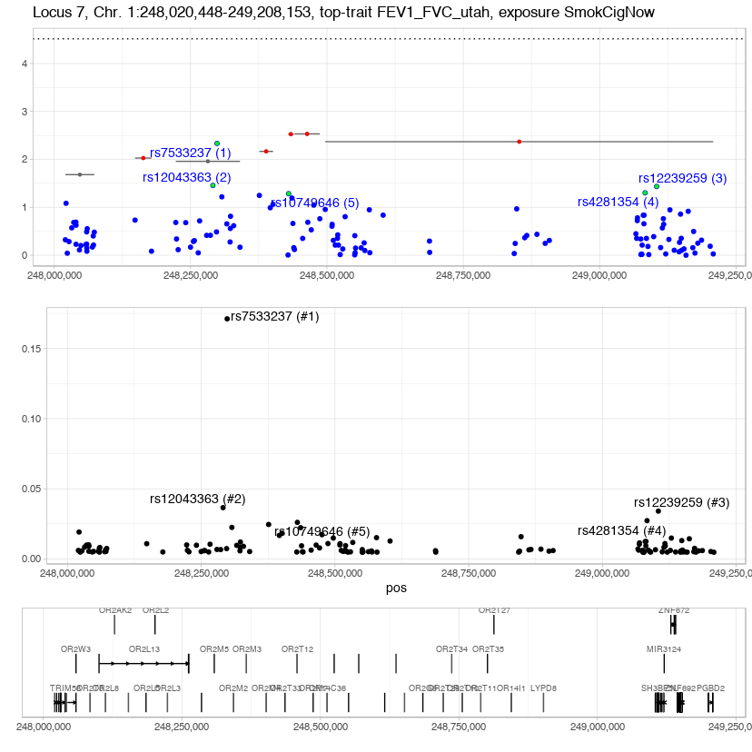

| snp | chr | pos | zscore | pval | snp_prob | snp_log10bf | zscore_acs | pval_acs | prop_zscore | prop_snp_prob |
| --- | --- | --- | --- | --- | --- | --- | --- | --- | --- | --- |
| rs7533237 | 1 | 248,298,552 | -2.831 | 0.004647 | 0.1711 | 1.226 | -2.543 | 0.01098 | 1 | 1 |
| rs12043363 | 1 | 248,290,903 | 2.108 | 0.03502 | 0.0366 | 0.4906 | -2.543 | 0.01098 | 1.343 | 4.675 |
| rs12239259 | 1 | 249,104,349 | 2.088 | 0.03678 | 0.0341 | 0.4595 | -2.857 | 0.004275 | 1.356 | 5.018 |
| rs4281354 | 1 | 249,083,236 | 1.961 | 0.0499 | 0.0273 | 0.3601 | -2.857 | 0.004275 | 1.444 | 6.267 |
| rs10749646 | 1 | 248,429,719 | 1.944 | 0.05195 | 0.0261 | 0.3396 | -2.97 | 0.00298 | 1.456 | 6.556 |

### 2.9.1 Overlap with methylation QTLs

NULL NULL NULL

| meth | snp | cpg | beta | pval | gene | chr | start_meth | end_meth | chr_snp | pos_snp |
| --- | --- | --- | --- | --- | --- | --- | --- | --- | --- | --- |
| trans_by_meth | rs9928829 | cg10818986 | -4.387 | 0 | OR2T8 | 1 | 248083098 | 248083147 | NA | NA |
| trans_by_meth | rs9650652 | cg10818986 | -3.666 | 0 | OR2T8 | 1 | 248083098 | 248083147 | NA | NA |
| trans_by_meth | rs9564096 | cg10818986 | -5.438 | 0 | OR2T8 | 1 | 248083098 | 248083147 | NA | NA |
| trans_by_meth | rs9399712 | cg05794927 | -8.541 | 0 | OR2W3 | 1 | 248059252 | 248059301 | NA | NA |
| trans_by_meth | rs9399704 | cg05794927 | -8.567 | 0 | OR2W3 | 1 | 248059252 | 248059301 | NA | NA |
| trans_by_meth | rs887375 | cg10818986 | -2.866 | 0 | OR2T8 | 1 | 248083098 | 248083147 | NA | NA |
| trans_by_meth | rs833402 | cg10818986 | -4.543 | 0 | OR2T8 | 1 | 248083098 | 248083147 | NA | NA |
| trans_by_meth | rs8068876 | cg15595212 | -10.29 | 0 | OR2L13 | 1 | 248100183 | 248100232 | NA | NA |
| trans_by_meth | rs7934873 | cg10818986 | -3.674 | 0 | OR2T8 | 1 | 248083098 | 248083147 | NA | NA |
| trans_by_meth | rs7761764 | cg10818986 | -3.272 | 0 | OR2T8 | 1 | 248083098 | 248083147 | NA | NA |
| trans_by_meth | rs774394 | cg10818986 | -11.11 | 0 | OR2T8 | 1 | 248083098 | 248083147 | NA | NA |
| trans_by_meth | rs7650116 | cg10818986 | -4.404 | 0 | OR2T8 | 1 | 248083098 | 248083147 | NA | NA |
| trans_by_meth | rs7595401 | cg15595212 | -10.26 | 0 | OR2L13 | 1 | 248100183 | 248100232 | NA | NA |
| trans_by_meth | rs7585296 | cg14013099 | -9.117 | 0 | OR2M5 | 1 | 248307268 | 248307317 | NA | NA |
| trans_by_meth | rs757702 | cg14013099 | -8.631 | 0 | OR2M5 | 1 | 248307268 | 248307317 | NA | NA |
| trans_by_meth | rs7561582 | cg14013099 | -9.049 | 0 | OR2M5 | 1 | 248307268 | 248307317 | NA | NA |
| trans_by_meth | rs740040 | cg14013099 | -8.625 | 0 | OR2M5 | 1 | 248307268 | 248307317 | NA | NA |
| trans_by_meth | rs7308651 | cg10818986 | -5.733 | 0 | OR2T8 | 1 | 248083098 | 248083147 | NA | NA |
| trans_by_meth | rs7212406 | cg15595212 | -10.26 | 0 | OR2L13 | 1 | 248100183 | 248100232 | NA | NA |
| trans_by_meth | rs7190256 | cg15595212 | -10.21 | 0 | OR2L13 | 1 | 248100183 | 248100232 | NA | NA |
| trans_by_meth | rs7174562 | cg15595212 | -10.19 | 0 | OR2L13 | 1 | 248100183 | 248100232 | NA | NA |
| trans_by_meth | rs7138234 | cg10818986 | -5.764 | 0 | OR2T8 | 1 | 248083098 | 248083147 | NA | NA |
| trans_by_meth | rs7122916 | cg15595212 | -5.578 | 0 | OR2L13 | 1 | 248100183 | 248100232 | NA | NA |
| trans_by_meth | rs7070767 | cg10818986 | -4.478 | 0 | OR2T8 | 1 | 248083098 | 248083147 | NA | NA |
| trans_by_meth | rs7012794 | cg15595212 | -10.27 | 0 | OR2L13 | 1 | 248100183 | 248100232 | NA | NA |
| trans_by_meth | rs6941418 | cg10818986 | -3.268 | 0 | OR2T8 | 1 | 248083098 | 248083147 | NA | NA |
| trans_by_meth | rs6938821 | cg10818986 | -11.39 | 0 | OR2T8 | 1 | 248083098 | 248083147 | NA | NA |
| trans_by_meth | rs6930853 | cg10818986 | -3.271 | 0 | OR2T8 | 1 | 248083098 | 248083147 | NA | NA |
| trans_by_meth | rs6912827 | cg10818986 | -3.255 | 0 | OR2T8 | 1 | 248083098 | 248083147 | NA | NA |
| trans_by_meth | rs689365 | cg10818986 | -211.2 | 0 | OR2T8 | 1 | 248083098 | 248083147 | NA | NA |

[output cut: 155 more lines]

| meth | snp | cpg | beta | pval | gene | chr | start_meth | end_meth | chr_snp | pos_snp |
| --- | --- | --- | --- | --- | --- | --- | --- | --- | --- | --- |
| trans_by_snp | rs6587444 | cg06929970 | 5.6 | 0 | NA | 1 | 1.82e+08 | 1.82e+08 | 1 | 248438452 |
| trans_by_snp | rs4359056 | cg24742912 | 11.85 | 0 | MYBPH | 1 | 203146346 | 203146395 | 1 | 248795852 |
| trans_by_snp | rs4359056 | cg08639434 | -10.34 | 0 | NA | 1 | 88054918 | 88054967 | 1 | 248795852 |
| trans_by_snp | rs4359056 | cg16250145 | -8.093 | 0 | FLJ40434 | 1 | 53906777 | 53906826 | 1 | 248795852 |
| trans_by_snp | rs10888287 | cg22853601 | -6.435 | 0 | KIAA1026 | 1 | 15162073 | 15162122 | 1 | 248117416 |
| trans_by_snp | rs10888287 | cg08110455 | -5.515 | 0 | NA | 1 | 23281822 | 23281871 | 1 | 248117416 |
| trans_by_snp | rs10888287 | cg17178126 | -5.253 | 0 | NA | 1 | 31331702 | 31331751 | 1 | 248117416 |
| trans_by_snp | rs4359056 | cg19456451 | -16.95 | NA | ZSWIM6 | 5 | 60699327 | 60699376 | 1 | 248795852 |
| trans_by_snp | rs4359056 | cg02543202 | -16.03 | NA | PTPN4 | 2 | 120516858 | 120516907 | 1 | 248795852 |
| trans_by_snp | rs4359056 | cg02600099 | -14.69 | NA | SIK2 | 11 | 111589673 | 111589722 | 1 | 248795852 |
| trans_by_snp | rs6587444 | cg00238818 | -8.136 | NA | PRR7 | 5 | 176880261 | 176880310 | 1 | 248438452 |
| trans_by_snp | rs10888287 | cg23491756 | -9.375 | NA | HCG26 | 6 | 31438151 | 31438200 | 1 | 248117416 |
| trans_by_snp | rs4359056 | cg08384920 | -12.29 | NA | ANKS3 | 16 | 4776922 | 4776971 | 1 | 248795852 |
| trans_by_snp | rs4359056 | cg04413872 | -11.69 | NA | TSTA3 | 8 | 144694911 | 144694960 | 1 | 248795852 |
| trans_by_snp | rs4359056 | cg04413872 | -11.69 | NA | TSTA3 | 8 | 144694911 | 144694960 | 1 | 248795852 |
| trans_by_snp | rs4359056 | cg12091339 | -11.83 | NA | GAS7 | 17 | 9821299 | 9821348 | 1 | 248795852 |
| trans_by_snp | rs4359056 | cg01717517 | -11.66 | NA | DNM1P35 | 15 | 76029699 | 76029748 | 1 | 248795852 |
| trans_by_snp | rs4359056 | cg13778743 | -11.41 | NA | TBKBP1 | 17 | 45787839 | 45787888 | 1 | 248795852 |
| trans_by_snp | rs10888287 | cg16446408 | 7.167 | NA | LASS6 | 2 | 169313621 | 169313670 | 1 | 248117416 |
| trans_by_snp | rs6587444 | cg15953187 | -6.524 | NA | MUC5B | 11 | 1256378 | 1256427 | 1 | 248438452 |
| trans_by_snp | rs6587444 | cg19118812 | 6.522 | NA | ELMO1 | 7 | 37488438 | 37488487 | 1 | 248438452 |
| trans_by_snp | rs6587444 | cg05590616 | 6.191 | NA | STX3 | 11 | 59522917 | 59522966 | 1 | 248438452 |
| trans_by_snp | rs4359056 | cg01768144 | -9.751 | NA | LOC100303728 | NA | 118601137 | 118601186 | 1 | 248795852 |
| trans_by_snp | rs6587444 | cg07048094 | -6.189 | NA | PTPRN2 | 7 | 157409033 | 157409082 | 1 | 248438452 |
| trans_by_snp | rs4359056 | cg05492975 | -10.14 | NA | CDH4 | 20 | 60119460 | 60119509 | 1 | 248795852 |
| trans_by_snp | rs10888287 | cg20248140 | -7.193 | NA | ARID3A | 19 | 929495 | 929544 | 1 | 248117416 |
| trans_by_snp | rs6587444 | cg27323091 | 5.707 | NA | KCNQ1OT1 | 11 | 2721571 | 2721620 | 1 | 248438452 |
| trans_by_snp | rs10888287 | cg08580380 | -5.159 | NA | FAM122B | NA | 133929484 | 133929533 | 1 | 248117416 |
| trans_by_snp | rs10888287 | cg04140297 | -6.886 | NA | SCRIB | 8 | 144874793 | 144874842 | 1 | 248117416 |
| trans_by_snp | rs10888287 | cg04140297 | -6.886 | NA | SCRIB | 8 | 144874793 | 144874842 | 1 | 248117416 |

[output cut: 73 more lines]